# Choosing the Regression Method

Lecture 11A

PUBHBIO 6250

## Choosing the Right Regression Method

Throwback to week 1: The type of **regression model** to use depends on the **outcome variable’s** data type:

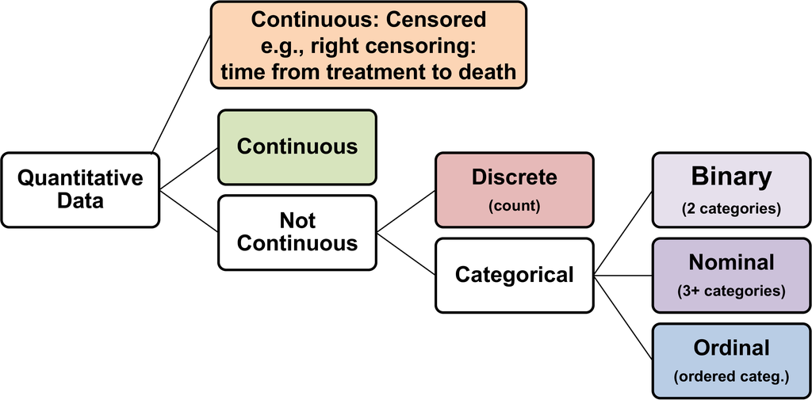

## A Series of Questions to Ask

Ask yourself, is the outcome $(Y)$…

- …chosen from a **category**?
  - Ex: ever used e-cigarettes; health status (good, fair, poor); state of residence
- …or are we **counting** something?
  - Ex: number of asthma attacks; number of car accidents
- …or are we measuring something along a **continuum**?
  - Ex: age; height; weight of a newborn; time to death

$\rightarrow$ Narrow down the analysis options, based on whether the outcome variable is categorical, a count, or a continuous measurement.

## Categorical: More Details

[figure not shown]

Note: we did not cover ordinal logistic or multinomial regression!

## Count: More Details

What is being modeled? Is it…

- **Average counts** – each count based on a common measurement period
  - Ex: number of ER visits in 1 month in a sample of people living in Columbus.
  - Counts are directly comparable (e.g., 5 is greater than 2!)
  - **Poisson regression – No offset needed**
- **Risks** – each count based on groups of different sizes
  - Ex: number of ER visits in a county.
  - Counts are **not** directly comparable (e.g., 500 might not be greater than 200, depends on population size)
  - **Poisson regression – Need offset = (log) population size**
- **Rates** – each count based on different amount of observation time
  - Ex: number of ER visits per year, where time on study differs by person.
  - Counts are **not** directly comparable (e.g., 5 might not be greater than 2, depends on how long a person was observed for)
  - **Poisson regression – Need offset = (log) person-time**

## Count: More Details – Are Assumptions Met?

Most common problem: **overdispersion**

- Variance of the observed counts $>$ mean of the observed counts after “adjusting for” or “controlling for” covariates $X$
  - $\text{Var}(Y|X) > E(Y|X)$
- Very common in real-world data
  - Often, there are unobserved predictors that – if we had them – would mean $Y|X$ is Poisson (i.e., no overdispersion)
  - But, we don’t observe them $\rightarrow$ results in overdispersion
- Solutions: Poisson regression with robust SEs or Negative binomial regression

Another possible problem: **too many zeros**

- Need alternative regression methods that separately model the 0s
- Solutions: Zero-truncated or zero-inflated Poisson/Negative binomial regression
  - *we did not focus on how to choose between these alternative options*

## Continuous: More Details

What is being modeled? Is it…

- **Complete/fully observed measurements** – most continuous outcomes, where we observe the actual outcome for each person
  - E.g., weight of a newborn in kilograms
  - E.g., time to run 1 mile
  - **Linear regression**
- **Censored observations** – we do not observe the actual outcome for some people, only that the measurement is greater than a certain amount
  - E.g., time to death, where some people’s deaths are not observed (e.g., drop out of study, or study ends and they are still alive)
  - **Cox proportional hazards regression**
    - Note: the “outcome” is actually captured by **two variables:** indicator of whether the event was observed (yes/no), and time to the event or censoring

## Some Special Cases

- For most binary variables we could use logistic regression – but make sure you don’t need survival analysis instead
  - Ex: dead vs. alive
    - all individuals observed for same length of time (full study period)
    - AND we know the true status (dead; alive) of everybody at the end of the study
    - $\rightarrow$ **logistic regression**
    - Concrete example: 30-day mortality after hospital discharge (assuming we know everyone’s status at 30 days)
  - Ex: dead vs. alive
    - individuals observed for different lengths of time
    - OR we don’t know the true status (dead; alive) of everybody at the end of the study (e.g., study dropout)
    - $\rightarrow$ **survival analysis / Cox PH regression**

## Some Special Cases

- For most time-to-event (continuous) variables we require survival analysis – but sometimes linear regression is an option
  - Ex: time to finishing a marathon
    - all runners cross the finish line and have a completion time observed
    - $\rightarrow$ **linear regression**
  - Ex: time to finishing a marathon
    - some runners do not finish the race
    - $\rightarrow$ **survival analysis / Cox PH regression**

## Additional Considerations

How the data were collected matters!

- All these methods assume **independence** of observations
  - Common data collection methods that violate independence:
    - Repeated measurements on individuals
    - Measurements from groups of people that can be expected to have similar outcomes (e.g., families, kids within schools)
  - Need alternate regression techniques that account for these correlated measurements
- If data were collected via a **complex sampling scheme**, need survey sample versions of the methods
  - Same “rules” about which regression method to use apply (e.g., binary outcome = logistic regression)
  - Just have to use the **survey-weighted version**!